# Geog533 Lab 10

Daniella Madubuike

## Question 1

Use R package UScensus2010county to complete the following tasks: (20 pt.)

### Question 1(a)

Plot a map of New York counties using the plot function.

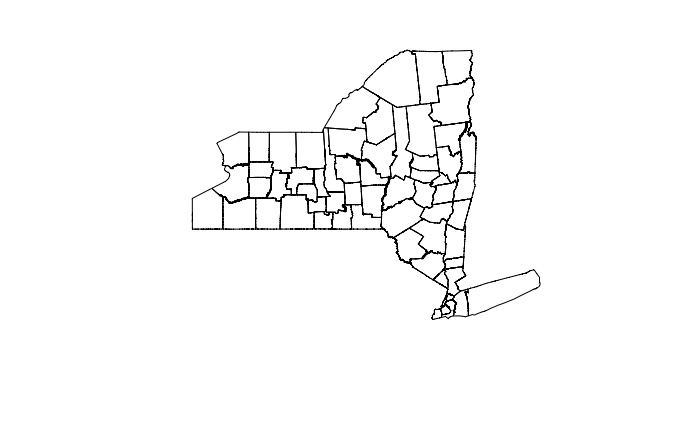

```r
### install packages
if(!require(UScensus2010)) install.packages("UScensus2010")
library(UScensus2010)
if(!require(UScensus2010county)) install.county("osx")
if(!require(UScensus2010tract)) install.tract("osx")
library(UScensus2010county)
library(UScensus2010tract)
data(new_york.county10)
shp <- new_york.county10
plot(shp)
```

### Question 1(b)

Plot a map of New York counties using the qtm function.

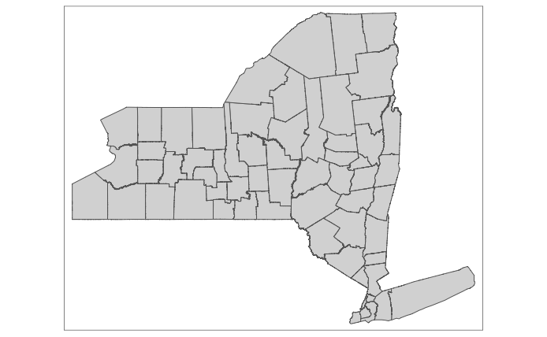

```r
if(!require(tmap)) install.packages("tmap")
library(tmap)
qtm(shp)
```

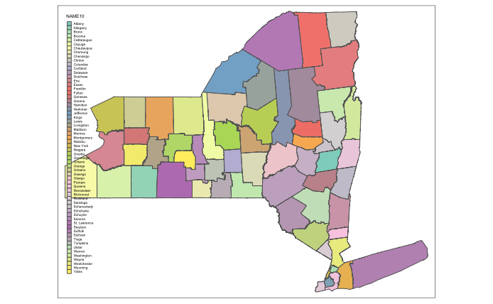

```r
qtm(shp,fill = "NAME10")
```

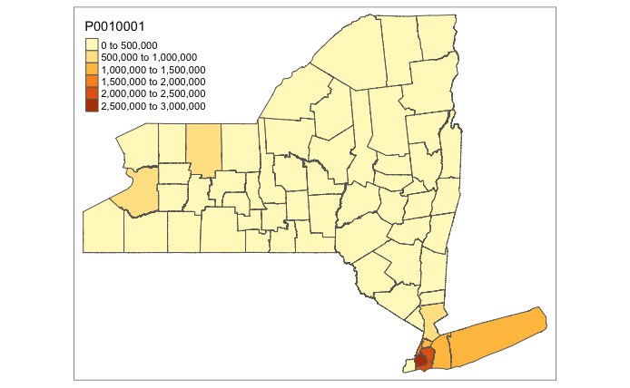

```r
qtm(shp,fill = "P0010001")
```

### Question 1(c)

How many counties in New York State?

```r
count <- shp$county
length(table(count))
```

```
[1] 62
```

### Question 1(d)

What’s the 3-digit fips code of Broome County?

```r
#if (shp$NAMELSAD10 == "Broome County") {
  #print(shp$county)}
boom <- shp$county == "Broome County"
```

[output not shown]

### Question 1(e)

Compute descriptive statistics of the population column (P0010001), including total, minimum, maximum, mean, median, and skewness.

```r
if(!require(fBasics)) install.packages("fBasics")
library(fBasics)
pop <- shp$P0010001
basicStats(pop)
```

|  | pop |
| --- | --- |
| nobs | 6.200000e+01 |
| NAs | 0.000000e+00 |
| Minimum | 4.836000e+03 |
| Maximum | 2.504700e+06 |
| 1. Quartile | 5.124350e+04 |
| 3. Quartile | 2.310602e+05 |
| Mean | 3.125500e+05 |
| Median | 9.130100e+04 |
| Sum | 1.937810e+07 |
| SE Mean | 6.760931e+04 |

[output cut: 6 more lines]

```r
summary(pop)
```

```
   Min. 1st Qu.  Median    Mean 3rd Qu.    Max.
   4836   51244   91301  312550  231060 2504700
```

### Question 1(f)

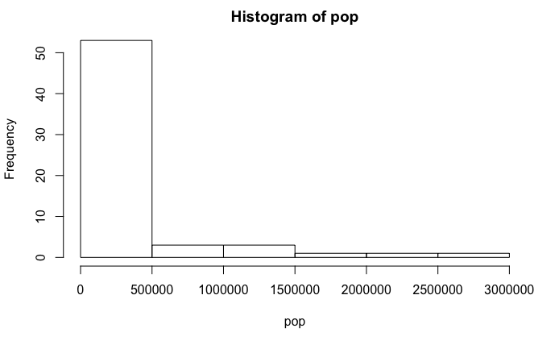

```r
hist(pop)
```

## Question 2

Use R package UScensus2010tract to complete the following tasks: (20 pt.)

### Question 2(a)

Plot a map of New York census tracts using the plot function.

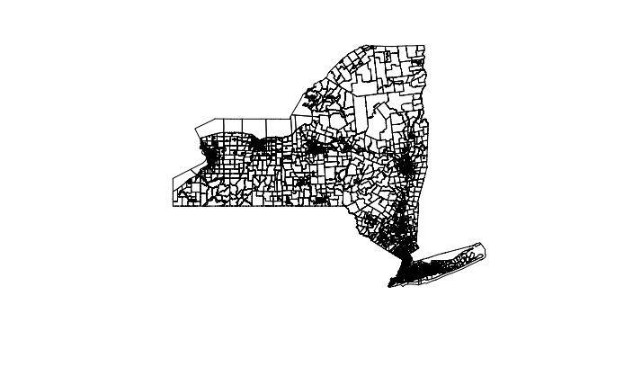

```r
if(!require(UScensus2010)) install.packages("UScensus2010")
library(UScensus2010)
if(!require(UScensus2010county)) install.county("osx")
if(!require(UScensus2010tract)) install.tract("osx")
library(UScensus2010county)
library(UScensus2010tract)
data(new_york.tract10)
shp <- new_york.tract10
df <- shp@data
plot(shp)
```

### Question 2(b)

Compute the total population based on census tracts.

```r
df <- shp@data
sum(pop)
```

```
[1] 19378102
```

### Question 2(c)

Select all census tracts in Broome County and plot the map.

```r
library(rgdal)
df <- shp@data
sel <- data.frame(df$county == "007")
shp[sel, ]
```

[output not shown]

### Question 2(d)

What’s the total population of Broome County?

```r
sum(sel)
```

[output not shown]

### Question 2(e)

Create a histogram and a boxplot of population based on census tracts of Broome County.

```r
df <- shp@data
sel <- df$county == "007"
shp[sel, ]
```

[output not shown]

```r
#hist(shp[sel,])
hist(sel)
```

[output not shown]

## Question 3

Use R packages raster and ncdf4 to complete the following tasks: (20 pt.)

### Question 3(a)

Load the multi-band raster dataset “NDVI.nc” into R.

```r
#setwd("Downloads/")
#getwd()
#if(!require(ncdf4)) install.packages("ncdf4")
#library(ncdf4)
#library(raster)
#ndvi.rb <- brick("GIMMS.NDVI.360.720.2000.2002.30days.nc")
#ndvi.rb
if(!require(ncdf4)) install.packages("ncdf4")
library(ncdf4)
library(rgdal)
library(raster)
multi <- raster("/Users/daniellamadubuike/Downloads/NDVI.nc/")
multi
```

```
class       : RasterLayer
band        : 1  (of  36  bands)
dimensions  : 360, 720, 259200  (nrow, ncol, ncell)
resolution  : 0.5, 0.5  (x, y)
extent      : -180, 180, -90, 90  (xmin, xmax, ymin, ymax)
coord. ref. : +proj=longlat +datum=WGS84 +ellps=WGS84 +towgs84=0,0,0
data source : /Users/daniellamadubuike/Downloads/NDVI.nc
names       : Normalized.Difference.Vegetation.Index
z-value     : 2000-01-01
zvar        : NDVI
```

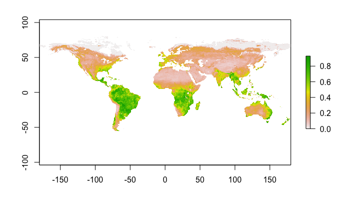

```r
plot(multi)
```

### Question 3(b)

Get the basic information about the dataset, including the number of rows, columns, cells, and bands; spatial resolution, extent, bounding box, and projection.

```r
nrow(multi)
```

```
[1] 360
```

```r
ncol(multi)
```

```
[1] 720
```

```r
ncell(multi)
```

```
[1] 259200
```

```r
extent(multi)
```

```
class       : Extent
xmin        : -180
xmax        : 180
ymin        : -90
ymax        : 90
```

```r
bbox(multi)
```

```
    min max
s1 -180 180
s2  -90  90
```

```r
res(multi)
```

```
[1] 0.5 0.5
```

```r
projection(multi)
```

```
[1] "+proj=longlat +datum=WGS84 +ellps=WGS84 +towgs84=0,0,0"
```

### Question 3(c)

Aggregate all bands to generate a mean NDVI raster and a maximum NDVI raster; save the two new raster datasets to the hard drive.

```r
meanmulti <- as.data.frame(cellStats(multi2,mean))
meanmulti
```

|  | cellStats(multi2, mean) |
| --- | --- |
| X2000.01.01 | 0.2587977 |
| X2000.02.01 | 0.2467688 |
| X2000.03.01 | 0.2588261 |
| X2000.04.01 | 0.3004263 |
| X2000.05.01 | 0.3921365 |
| X2000.06.01 | 0.4640384 |
| X2000.07.01 | 0.4946401 |
| X2000.08.01 | 0.4864491 |
| X2000.09.01 | 0.4271608 |
| X2000.10.01 | 0.2955579 |

[output cut: 26 more lines]

```r
maxmulti <- as.data.frame(cellStats(multi2,max))
maxmulti
```

| cellStats(multi2, max) |
| --- |
| 0.9289000 |
| 0.9383000 |
| 0.9216000 |
| 0.9421000 |
| 0.9439000 |
| 0.9333000 |
| 0.9500000 |
| 0.9268000 |
| 0.9083999 |
| 0.9050999 |

[output cut: 26 more lines]

```r
writeRaster(meanmulti, filename = "meanmult.grd")
```

[output not shown]

### Question 3(d)

Plot the maps of monthly NDVI of the year 2001

```r
multi2 <- brick("/Users/daniellamadubuike/Downloads/NDVI.nc/")
multi2
```

```
class       : RasterBrick
dimensions  : 360, 720, 259200, 36  (nrow, ncol, ncell, nlayers)
resolution  : 0.5, 0.5  (x, y)
extent      : -180, 180, -90, 90  (xmin, xmax, ymin, ymax)
coord. ref. : +proj=longlat +datum=WGS84 +ellps=WGS84 +towgs84=0,0,0
data source : /Users/daniellamadubuike/Downloads/NDVI.nc
names       : X2000.01.01, X2000.02.01, X2000.03.01, X2000.04.01, X2000.05.01, X2000.06.01, X2000.07.01, X2000.08.01, X2000.09.01, X2000.10.01, X2000.11.01, X2000.12.01, X2001.01.01, X2001.02.01, X2001.03.01, ...
Date        : 2000-01-01, 2002-12-01 (min, max)
varname     : NDVI
```

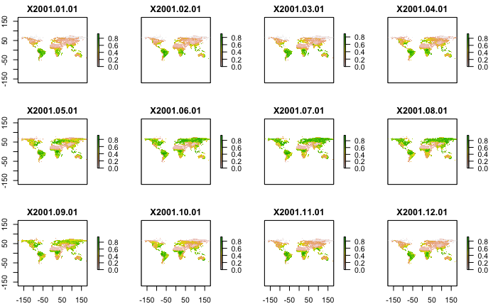

```r
multi3 <- multi2[[13:24]] # select bands as a new raster
plot(multi2, 13:24)
```

### Question 3(e)

Create histograms of monthly NDVI of the year 2001.

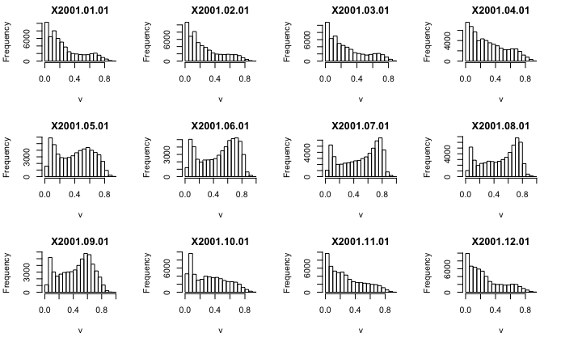

```r
hist(multi2, 13:24)
```

### Question 3(f)

Plot the NDVI map of July 2000; click any location with data on the map and retrieve the NDVI time series for all years; plot the NDVI time series of the selected location.

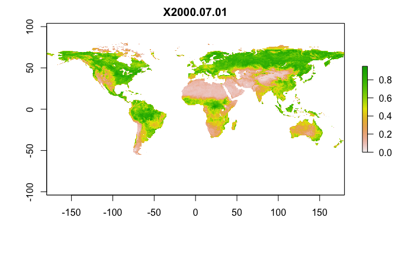

```r
plot(multi2, 7)
values <- click(multi2, n=1, xy=TRUE)
```

```r
#values <- click(multi2, n=1, xy=FALSE)
plot(as.vector(values), type="b")
```

[output not shown]